# Economic and Health Impact of Weather Events Accross the USA from 1950 to 2011

#### Synopsis

##### The purpose of this project is to analyze the health and economic impact of weather events accross the USA from 1950 to 2011 using the U.S. National Oceanic and Atmospheric Administration’s (NOAA) storm database.

##### This database collects characteristics of major storms and weather events in the United States, as well as estimates of any fatalities, injuries, property and crop damage starting in the year 1950 and ending in November 2011.

##### After cleaning the data and grouping by type of event, the total number of fatalities, injuries, property damages and crop damages for each category are shown in 2 separate panels. Overall, tornadoes cause the largest number of injuries and fatalities, while floods cause the most property damage, and drought causes the most damage to crops.

#### Data Processing

##### The analysis was performed on

[Storm Events Database](http://www.ncdc.noaa.gov/stormevents/ftp.jsp). The data is from a file available [here](https://d396qusza40orc.cloudfront.net/repdata%2Fdata%2FStormData.csv.bz2). There is also some documentation of the data available [here](https://d396qusza40orc.cloudfront.net/repdata%2Fpeer2_doc%2Fpd01016005curr.pdf).

##### The first step is to download the file if it doesn’t already exist in the working directory folder, and read the data.

```r
if (!file.exists("repdata_data_StormData.csv.bz2")) {
  download.file("https://d396qusza40orc.cloudfront.net/repdata%2Fdata%2FStormData.csv.bz2", destfile="repdata_data_StormData.csv.bz2")
}
if (!exists('stormdata')) {
  stormdata <- read.csv("repdata_data_StormData.csv.bz2")
}
str(stormdata)
```

```
## 'data.frame':    902297 obs. of  37 variables:
##  $ STATE__   : num  1 1 1 1 1 1 1 1 1 1 ...
##  $ BGN_DATE  : Factor w/ 16335 levels "1/1/1966 0:00:00",..: 6523 6523 4242 11116 2224 2224 2260 383 3980 3980 ...
##  $ BGN_TIME  : Factor w/ 3608 levels "00:00:00 AM",..: 272 287 2705 1683 2584 3186 242 1683 3186 3186 ...
##  $ TIME_ZONE : Factor w/ 22 levels "ADT","AKS","AST",..: 7 7 7 7 7 7 7 7 7 7 ...
##  $ COUNTY    : num  97 3 57 89 43 77 9 123 125 57 ...
##  $ COUNTYNAME: Factor w/ 29601 levels "","5NM E OF MACKINAC BRIDGE TO PRESQUE ISLE LT MI",..: 13513 1873 4598 10592 4372 10094 1973 23873 24418 4598 ...
##  $ STATE     : Factor w/ 72 levels "AK","AL","AM",..: 2 2 2 2 2 2 2 2 2 2 ...
##  $ EVTYPE    : Factor w/ 985 levels "   HIGH SURF ADVISORY",..: 834 834 834 834 834 834 834 834 834 834 ...
##  $ BGN_RANGE : num  0 0 0 0 0 0 0 0 0 0 ...
##  $ BGN_AZI   : Factor w/ 35 levels "","  N"," NW",..: 1 1 1 1 1 1 1 1 1 1 ...
##  $ BGN_LOCATI: Factor w/ 54429 levels "","- 1 N Albion",..: 1 1 1 1 1 1 1 1 1 1 ...
##  $ END_DATE  : Factor w/ 6663 levels "","1/1/1993 0:00:00",..: 1 1 1 1 1 1 1 1 1 1 ...
##  $ END_TIME  : Factor w/ 3647 levels ""," 0900CST",..: 1 1 1 1 1 1 1 1 1 1 ...
##  $ COUNTY_END: num  0 0 0 0 0 0 0 0 0 0 ...
```

[output cut: 23 more lines]

##### The second step is to subset the data according to the to columns of interest, which are EVTYPE, FATALITIES, INJURIES, PROPDMG, PROPDMGEXP, CROPDMG & CROPDMGEXP.

```r
my_vars <- c("EVTYPE", "FATALITIES", "INJURIES", "PROPDMG", "PROPDMGEXP", "CROPDMG", "CROPDMGEXP")
newdata <- stormdata[my_vars]
head(newdata)
```

```
##    EVTYPE FATALITIES INJURIES PROPDMG PROPDMGEXP CROPDMG CROPDMGEXP
## 1 TORNADO          0       15    25.0          K       0
## 2 TORNADO          0        0     2.5          K       0
## 3 TORNADO          0        2    25.0          K       0
## 4 TORNADO          0        2     2.5          K       0
## 5 TORNADO          0        2     2.5          K       0
## 6 TORNADO          0        6     2.5          K       0
```

##### In order to avoid duplicates, the following columns are converted to lower case:

```r
newdata$EVTYPE <- tolower(newdata$EVTYPE)
newdata$PROPDMGEXP <- tolower(newdata$PROPDMGEXP)
newdata$CROPDMGEXP <- tolower(newdata$CROPDMGEXP)
```

##### Let’s load the needed packages.

```r
library(dplyr)
```

```r
library(ggplot2)
library(gridExtra)
```

#### Analysis

##### Question 1: Across the United States, which types of events (as indicated in the EVTYPE variable) are most harmful with respect to population health?

##### I decided to calculate both the number of injuries and the number of fatalities for each type of event.

```r
#Let's calculate number of injuries per event type
injuries<- aggregate(INJURIES ~ EVTYPE, newdata, sum, na.rm = TRUE)

#Select the top 10 events with the most injuries
top_injuries <- head(arrange(injuries, desc(INJURIES)), 10)
top_injuries
```

```
##               EVTYPE INJURIES
## 1            tornado    91346
## 2          tstm wind     6957
## 3              flood     6789
## 4     excessive heat     6525
## 5          lightning     5230
## 6               heat     2100
## 7          ice storm     1975
## 8        flash flood     1777
## 9  thunderstorm wind     1488
## 10              hail     1361
```

```r
#Calculate number of fatalities per event type
fatalities <- aggregate(FATALITIES ~ EVTYPE, newdata, sum, na.rm = TRUE)

#Select the top 10 events with the most fatalities
top_fatalities <- head(arrange(fatalities, desc(FATALITIES)), 10)
top_fatalities
```

```
##            EVTYPE FATALITIES
## 1         tornado       5633
## 2  excessive heat       1903
## 3     flash flood        978
## 4            heat        937
## 5       lightning        816
## 6       tstm wind        504
## 7           flood        470
## 8     rip current        368
## 9       high wind        248
## 10      avalanche        224
```

#### Question 2: Across the United States, which types of events have the greatest economic consequences?

##### I decided to calculate both the property damages and the crop damages for each type of event.

##### According to the documentation, the PROPDMGEXP and CROPDMGEXP are used to signify the magnitude of PROPDMG and CROPDMG respectively, where K means 1000, M means one million, and B means one billion according to the documentation.

##### However there are extra values present as shown below. The extra values will be disregarded.

```r
unique(newdata$PROPDMGEXP)
```

```
##  [1] "k" "m" ""  "b" "+" "0" "5" "6" "?" "4" "2" "3" "h" "7" "-" "1" "8"
```

```r
unique(newdata$CROPDMGEXP)
```

```
## [1] ""  "m" "k" "b" "?" "0" "2"
```

##### Now I can eliminate all the values that are Os and NAs for PROPDMG and CROPDMG, and the values that are incorrect for PROPDMGEXP and CROPDMGEXP.

```r
prop_data <- subset(newdata, newdata$PROPDMG > 0 & newdata$PROPDMGEXP %in% c("h", "k", "m", "b"), na.rm = TRUE)
crop_data <- subset(newdata, newdata$CROPDMG > 0 & newdata$CROPDMGEXP %in% c("h", "k", "m", "b"), na.rm = TRUE)
```

##### Next, let’s calculate the property damages & crop damages by multiplying PROPDMG and CROPDMG with the appropriate coeffecient.

```r
#I created a loop that checks for h, k, m & b, and creates a new column propdamage and cropdamage.

for (i in 1:nrow(prop_data)) {
  if (prop_data$PROPDMGEXP[i] == "h")
    prop_data$propdamage[i] = prop_data$PROPDMG[i] * 100
  else if (prop_data$PROPDMGEXP[i] == "k")
    prop_data$propdamage[i] = prop_data$PROPDMG[i] * 1000
  else if (prop_data$PROPDMGEXP[i] == "m")
    prop_data$propdamage[i] = prop_data$PROPDMG[i] * 1000000
  else if (prop_data$PROPDMGEXP[i] == "b")
  prop_data$propdamage[i] = prop_data$PROPDMG[i] * 1000000000
  else prop_data$propdamage[i] = prop_data$PROPDMG[i]
}
head(prop_data)
```

```
##    EVTYPE FATALITIES INJURIES PROPDMG PROPDMGEXP CROPDMG CROPDMGEXP
## 1 tornado          0       15    25.0          k       0
## 2 tornado          0        0     2.5          k       0
## 3 tornado          0        2    25.0          k       0
## 4 tornado          0        2     2.5          k       0
## 5 tornado          0        2     2.5          k       0
## 6 tornado          0        6     2.5          k       0
##   propdamage
## 1      25000
## 2       2500
## 3      25000
## 4       2500
## 5       2500
## 6       2500
```

```r
for (i in 1:nrow(crop_data)) {
  if (crop_data$CROPDMGEXP[i] == "h")
    crop_data$cropdamage[i] = crop_data$CROPDMG[i] * 100
  else if (crop_data$CROPDMGEXP[i] == "k")
    crop_data$cropdamage[i] = crop_data$CROPDMG[i] * 1000
  else if (crop_data$CROPDMGEXP[i] == "m")
    crop_data$cropdamage[i] = crop_data$CROPDMG[i] * 1000000
  else if (crop_data$CROPDMGEXP[i] == "b")
  crop_data$cropdamage[i] = crop_data$CROPDMG[i] * 1000000000
  else crop_data$cropdamage[i] = crop_data$CROPDMG[i]
}

head(crop_data)
```

```
##                           EVTYPE FATALITIES INJURIES PROPDMG PROPDMGEXP
## 187566 hurricane opal/high winds          2        0     0.1          b
## 187571        thunderstorm winds          0        0     5.0          m
## 187581            hurricane erin          0        0    25.0          m
## 187583            hurricane opal          0        0    48.0          m
## 187584            hurricane opal          0        0    20.0          m
## 187653        thunderstorm winds          0        0    50.0          k
##        CROPDMG CROPDMGEXP cropdamage
## 187566      10          m      1e+07
## 187571     500          k      5e+05
## 187581       1          m      1e+06
## 187583       4          m      4e+06
## 187584      10          m      1e+07
## 187653      50          k      5e+04
```

```r
#Calculate the property damages per event type
properties <- aggregate(propdamage ~ EVTYPE, prop_data, sum, na.rm = TRUE)

#Arrange by the top 10 events causing the most damage
top_properties <- head(arrange(properties, desc(propdamage)), 10)
top_properties
```

```
##               EVTYPE   propdamage
## 1              flood 144657709800
## 2  hurricane/typhoon  69305840000
## 3            tornado  56937160480
## 4        storm surge  43323536000
## 5        flash flood  16140811510
## 6               hail  15732267220
## 7          hurricane  11868319010
## 8     tropical storm   7703890550
## 9       winter storm   6688497250
## 10         high wind   5270046260
```

```r
#Calculate the crop damages per event type
crop <- aggregate(cropdamage ~ EVTYPE, crop_data, sum, na.rm = TRUE)

#Arrange by the top 10 events causing the most damage
top_crop <- head(arrange(crop, desc(cropdamage)), 10)
top_crop
```

```
##               EVTYPE  cropdamage
## 1            drought 13972566000
## 2              flood  5661968450
## 3        river flood  5029459000
## 4          ice storm  5022113500
## 5               hail  3025954450
## 6          hurricane  2741910000
## 7  hurricane/typhoon  2607872800
## 8        flash flood  1421317100
## 9       extreme cold  1312973000
## 10      frost/freeze  1094186000
```

#### Results

##### Let’s plot the top 10 events with the most injuries and the most fatalities.

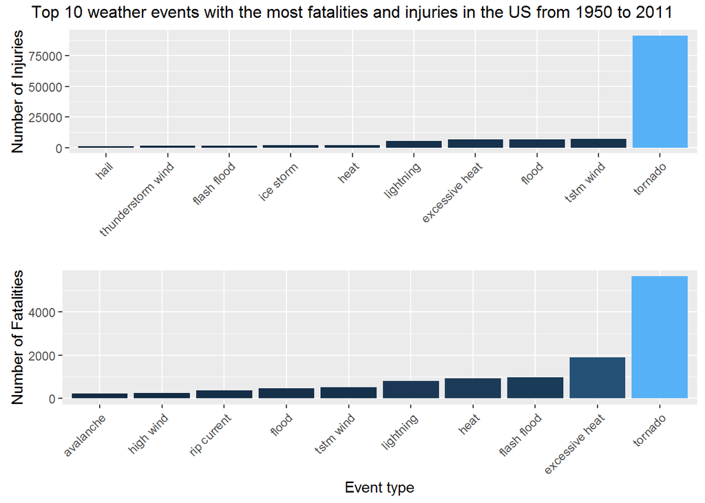

```r
plot1 <- ggplot(top_injuries, aes(x=reorder(EVTYPE, INJURIES), y=INJURIES, fill = INJURIES)) +
  geom_bar(stat = "identity") +
  xlab("") +
  ylab("Number of Injuries") +
  theme(axis.text.x=element_text(angle=45, hjust=1)) +
  theme(legend.position="none")

plot2 <- ggplot(top_fatalities, aes(x=reorder(EVTYPE, FATALITIES), y=FATALITIES, fill=FATALITIES)) +
  geom_bar(stat = "identity") +
  xlab("Event type") +
  ylab("Number of Fatalities") +
  theme(axis.text.x=element_text(angle=45, hjust=1)) +
  theme(legend.position="none")

grid.arrange(plot1, plot2, top="Top 10 weather events with the most fatalities and injuries in the US from 1950 to 2011")
```

#### Finally, let’s plot the top 10 events with the most property and crop damages.

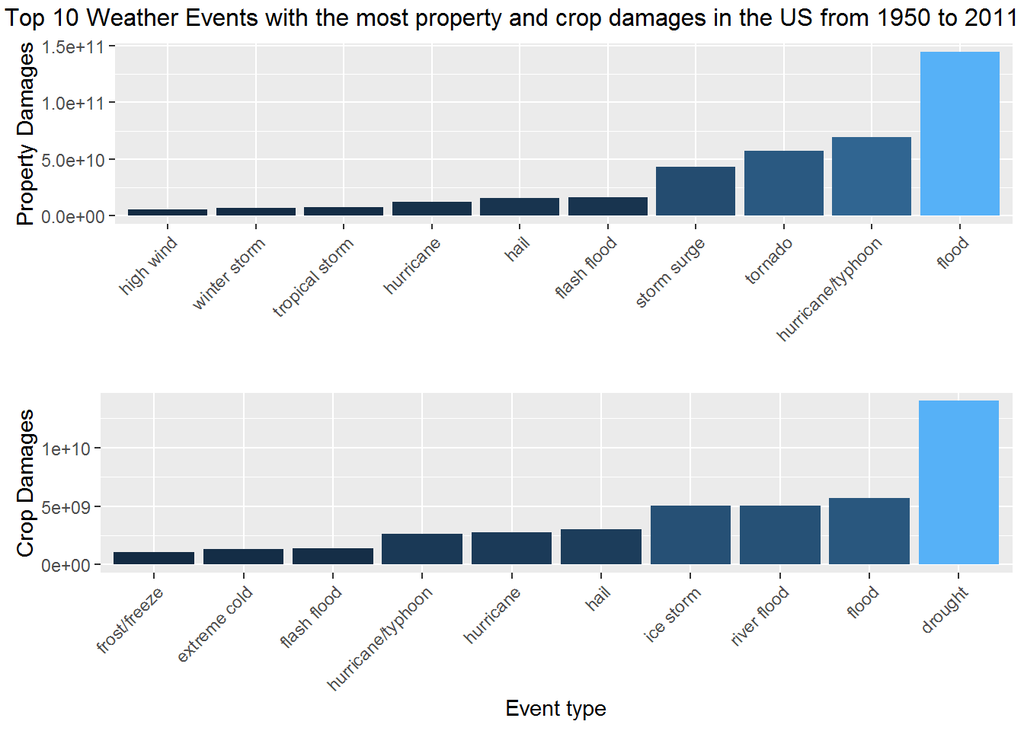

```r
plot3 <- ggplot(top_properties, aes(x=reorder(EVTYPE, propdamage), y=propdamage, fill=propdamage)) +
  geom_bar(stat = "identity") +
  xlab("") +
  ylab("Property Damages") +
  theme(axis.text.x=element_text(angle=45, hjust=1)) +
  theme(legend.position="none")

plot4 <- ggplot(top_crop, aes(x=reorder(EVTYPE, cropdamage), y=cropdamage, fill=cropdamage)) +
  geom_bar(stat = "identity") +
  xlab("Event type") +
  ylab("Crop Damages") +
  theme(axis.text.x=element_text(angle=45, hjust=1)) +
  theme(legend.position="none")

grid.arrange(plot3, plot4, top="Top 10 Weather Events with the most property and crop damages in the US from 1950 to 2011")
```

#### Conclusion

##### As we can see from the graphs, tornadoes are responsible for the highest number of fatalities and injuries, while flood is reponsible for the most property damages, and drought is the cause of the most crop damages.